# Lab 04 - La Quinta is Spanish for next to Denny’s, Pt. 1

Next, let’s calculate which states have the most Denny’s locations *per thousand square miles*. This requires *joining* information from the frequency tables you created in Exercise 8 with information from the `states` data frame.

First, we count how many observations are in each state, which will give us a data frame with two variables: `state` and `n`. Then, we join this data frame with the `states` data frame. However note that the variables in the `states` data frame that has the two-letter abbreviations is called `abbreviation`. So when we’re joining the two data frames we specify that the `state` variable from the Denny’s data should be matched `by` the `abbreviation` variable from the `states` data:

```r
dennys %>%
  count(state) %>%
  inner_join(states, by = c("state" = "abbreviation"))
```

```
## # A tibble: 51 × 4
##    state     n name                     area
##    <chr> <int> <chr>                   <dbl>
##  1 AK        3 Alaska               665384.
##  2 AL        7 Alabama               52420.
##  3 AR        9 Arkansas              53179.
##  4 AZ       83 Arizona              113990.
##  5 CA      403 California           163695.
##  6 CO       29 Colorado             104094.
##  7 CT       12 Connecticut            5543.
##  8 DC        2 District of Columbia     68.3
##  9 DE        1 Delaware               2489.
## 10 FL      140 Florida               65758.
## # ℹ 41 more rows
```

Before you move on the the next question, run the code above and take a look at the output. In the next exercise you will need to build on this pipe.

```r
# Denny's locations by state
dennys_by_state <- dennys %>%
  count(state, sort = TRUE)

# Top 5 states with most Denny's
cat("Top 5 states with most Denny's:\n")
```

```
## Top 5 states with most Denny's:
```

```r
head(dennys_by_state, 5)
```

```
## # A tibble: 5 × 2
##   state     n
##   <chr> <int>
## 1 CA      403
## 2 TX      200
## 3 FL      140
## 4 AZ       83
## 5 IL       56
```

```r
# Bottom 5 states with fewest Denny's
cat("\nStates with fewest Denny's:\n")
```

```
##
## States with fewest Denny's:
```

```r
tail(dennys_by_state, 5)
```

```
## # A tibble: 5 × 2
##   state     n
##   <chr> <int>
## 1 SD        3
## 2 WV        3
## 3 DC        2
## 4 VT        2
## 5 DE        1
```

```r
# La Quinta locations by state (US only)
laquinta_by_state <- laquinta %>%
  filter(country == "United States") %>%
  count(state, sort = TRUE)

# Top 5 states with most La Quinta
cat("Top 5 states with most La Quinta:\n")
```

```
## Top 5 states with most La Quinta:
```

```r
head(laquinta_by_state, 5)
```

```
## # A tibble: 5 × 2
##   state     n
##   <chr> <int>
## 1 TX      237
## 2 FL       74
## 3 CA       56
## 4 GA       41
## 5 TN       30
```

```r
# Bottom 5 states with fewest La Quinta
cat("\nStates with fewest La Quinta:\n")
```

```
##
## States with fewest La Quinta:
```

```r
tail(laquinta_by_state, 5)
```

```
## # A tibble: 5 × 2
##   state     n
##   <chr> <int>
## 1 NH        2
## 2 RI        2
## 3 SD        2
## 4 VT        2
## 5 ME        1
```

This is not surprising because: - Both chains have many locations in California and Texas, which are large states with high populations - States like Delaware and Vermont have few locations, which makes sense given their smaller size and population - The distribution reflects population density and tourism patterns

10. Which states have the most Denny’s locations per thousand square miles? What about La Quinta?

Next, we put the two datasets together into a single data frame. However before we do so, we need to add an identifier variable. We’ll call this `establishment` and set the value to `"Denny's"` and `"La Quinta"` for the `dennys` and `laquinta` data frames, respectively.

```r
dennys <- dennys %>%
  mutate(establishment = "Denny's")
laquinta <- laquinta %>%
  mutate(establishment = "La Quinta")
```

Since the two data frames have the same columns, we can easily bind them with the `bind_rows` function:

```r
dn_lq <- bind_rows(dennys, laquinta)
```

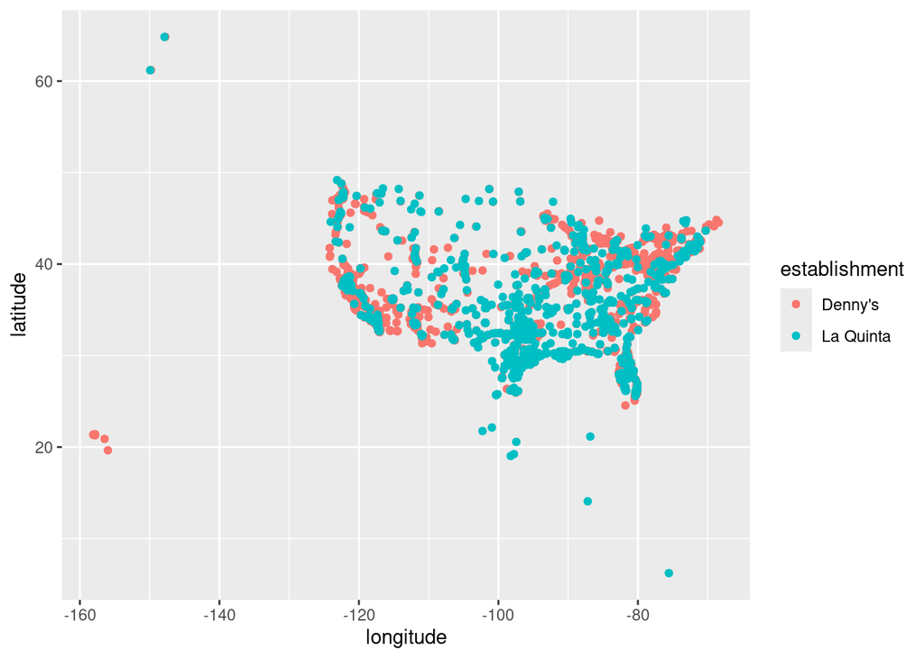

```r
ggplot(dn_lq, mapping = aes(x = longitude,
                            y = latitude,
                            color = establishment)) +
  geom_point()
```

The following two questions ask you to create visualizations. These should follow best practices you learned in class, such as informative titles, axis labels, etc. See http://ggplot2.tidyverse.org/reference/labs.html for help with the syntax. You can also choose different themes to change the overall look of your plots, see http://ggplot2.tidyverse.org/reference/ggtheme.html for help with these.

```r
# Denny's per thousand square miles
dennys_per_area <- dennys %>%
  count(state) %>%
  inner_join(states, by = c("state" = "abbreviation")) %>%
  mutate(locations_per_1000sqmi = n / (area / 1000)) %>%
  arrange(desc(locations_per_1000sqmi))

# Top 5 states by Denny's density
cat("Top 5 states by Denny's per 1000 square miles:\n")
```

```
## Top 5 states by Denny's per 1000 square miles:
```

```r
head(dennys_per_area %>% select(state, n, area, locations_per_1000sqmi), 5)
```

```
## # A tibble: 5 × 4
##   state     n     area locations_per_1000sqmi
##   <chr> <int>    <dbl>                  <dbl>
## 1 DC        2     68.3                  29.3
## 2 RI        5   1545.                    3.24
## 3 CA      403 163695.                    2.46
## 4 CT       12   5543.                    2.16
## 5 FL      140  65758.                    2.13
```

```r
# La Quinta per thousand square miles
laquinta_per_area <- laquinta %>%
  filter(country == "United States") %>%
  count(state) %>%
  inner_join(states, by = c("state" = "abbreviation")) %>%
  mutate(locations_per_1000sqmi = n / (area / 1000)) %>%
  arrange(desc(locations_per_1000sqmi))

# Top 5 states by La Quinta density
cat("Top 5 states by La Quinta per 1000 square miles:\n")
```

```
## Top 5 states by La Quinta per 1000 square miles:
```

```r
head(laquinta_per_area %>% select(state, n, area, locations_per_1000sqmi), 5)
```

```
## # A tibble: 5 × 4
##   state     n    area locations_per_1000sqmi
##   <chr> <int>   <dbl>                  <dbl>
## 1 RI        2   1545.                  1.29
## 2 FL       74  65758.                  1.13
## 3 CT        6   5543.                  1.08
## 4 MD       13  12406.                  1.05
## 5 TX      237 268596.                  0.882
```

Rhode Island and DC have high densities due to their small areas. Adjusting for area gives us a different perspective on concentration.

11. Filter the data for observations in North Carolina only, and recreate the plot. You should also adjust the transparency of the points, by setting the `alpha` level, so that it’s easier to see the overplotted ones. Visually, does Mitch Hedberg’s joke appear to hold here?

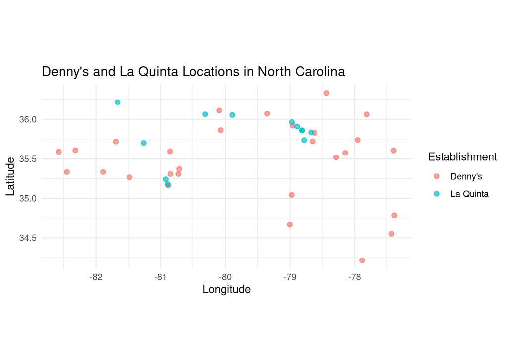

```r
dn_lq %>%
  filter(state == "NC") %>%
  ggplot(mapping = aes(x = longitude, y = latitude, color = establishment)) +
  geom_point(alpha = 0.7, size = 2) +
  labs(
    title = "Denny's and La Quinta Locations in North Carolina",
    x = "Longitude",
    y = "Latitude",
    color = "Establishment"
  ) +
  theme_minimal() +
  coord_quickmap()  # Alternative that doesn't require mapproj
```

Looking at the North Carolina plot, there does appear to be some clustering of Denny’s and La Quinta locations, particularly around major cities and along interstate corridors. However, the pattern isn’t overwhelming - there are many Denny’s without nearby La Quintas and vice versa. The joke partially holds but isn’t a universal truth.

12. Now filter the data for observations in Texas only, and recreate the plot, with an appropriate `alpha` level. Visually, does Mitch Hedberg’s joke appear to hold here?

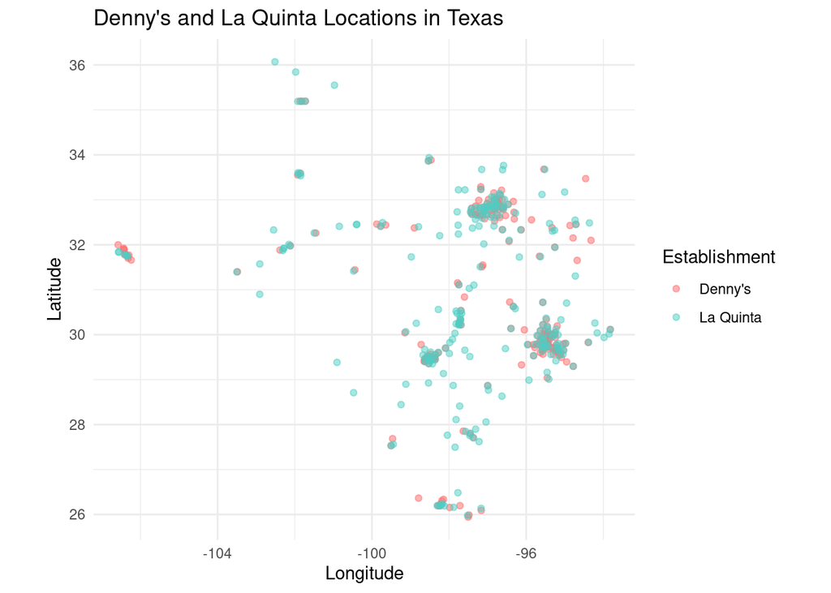

```r
dn_lq %>%
  filter(state == "TX") %>%
  ggplot(mapping = aes(x = longitude, y = latitude, color = establishment)) +
  geom_point(alpha = 0.5, size = 1.5) +
  labs(
    title = "Denny's and La Quinta Locations in Texas",
    x = "Longitude",
    y = "Latitude",
    color = "Establishment"
  ) +
  theme_minimal() +
  coord_quickmap() +  # Alternative that doesn't require mapproj
  scale_color_manual(values = c("Denny's" = "#FF6B6B", "La Quinta" = "#4ECDC4"))
```

In Texas, with many more locations of both establishments, we can see some clustering patterns, especially in major metropolitan areas like Houston, Dallas, Austin, and San Antonio. There does appear to be some tendency for the two chains to locate near each other, particularly along major highways. However, there are also many locations of each chain that are not near the other. The joke seems to have some basis in reality but is an exaggeration.

That’s it for now! In the next lab we will take a more quantitative approach to answering these questions.

🧶 ✅ ⬆️ Knit, *commit, and push your changes to GitHub with an appropriate commit message. Make sure to commit and push all changed files so that your Git pane is cleared up afterwards and review the md document on GitHub to make sure you’re happy with the final state of your work.*

Now go back through your write up to make sure you’ve answered all questions and all of your R chunks are properly labeled. Once you decide that you are done with the lab, choose the knit drop down and select `Knit to tufte_handout` to generate a pdf. Download and submit that pdf to Canvas.